# IP Week 12

Christine Kandeo

1/21/2022

# Specific Data Analytics Question

Understanding the characteristics of Users that are likely to click on advertisements

# Metrics for Success

Accurately identifying variables that likely lead to a customer clicking an ad

# Understanding the Context

A Kenyan entrepreneur has created an online cryptography course and would want to advertise it on her blog. She currently targets audiences originating from various countries. In the past, she ran ads to advertise a related course on the same blog and collected data in the process. She would like to identify which individuals are most likely to click on her ads.

# Experimental Design

1.Data Preparation

- Loading the dataset
- Data Uniformity
- Handling Missing/Duplicate Values
- Checking Outliers

2.Exploratory Data Analysis

- Univariate Analysis
- Bivariate Analysis

3.Conclusions and Recommendations

# Data Relevance

# 1. Data Preparation

Loading Libraries

```r
#For
library(tidyverse)
```

Loading the Data set

```r
#Importing the data to the Global Environment:
Adv <- read.csv("http://bit.ly/IPAdvertisingData", header = TRUE, sep = ",")

#Printing the first 4 rows of the dataframe
head(Adv, n=4)
```

```
##   Daily.Time.Spent.on.Site Age Area.Income Daily.Internet.Usage
## 1                    68.95  35    61833.90               256.09
## 2                    80.23  31    68441.85               193.77
## 3                    69.47  26    59785.94               236.50
## 4                    74.15  29    54806.18               245.89
##                           Ad.Topic.Line           City Male    Country
## 1    Cloned 5thgeneration orchestration    Wrightburgh    0    Tunisia
## 2    Monitored national standardization      West Jodi    1      Nauru
## 3      Organic bottom-line service-desk       Davidton    0 San Marino
## 4 Triple-buffered reciprocal time-frame West Terrifurt    1      Italy
##             Timestamp Clicked.on.Ad
## 1 2016-03-27 00:53:11             0
## 2 2016-04-04 01:39:02             0
## 3 2016-03-13 20:35:42             0
## 4 2016-01-10 02:31:19             0
```

```r
#Checking the Number of Rows and Columns:
dim(Adv)
```

```
## [1] 1000   10
```

Data Uniformity

```r
#Getting Information on the data types on each respective columns:
sapply(Adv, class)
```

```
## Daily.Time.Spent.on.Site                      Age              Area.Income
##                "numeric"                "integer"                "numeric"
##     Daily.Internet.Usage            Ad.Topic.Line                     City
##                "numeric"              "character"              "character"
##                     Male                  Country                Timestamp
##                "integer"              "character"              "character"
##            Clicked.on.Ad
##                "integer"
```

```r
#Renaming the Male column to Gender for ease of reference:
names(Adv)[names(Adv) == 'Male'] <- 'Gender'
```

```r
#Viewing the final information:
str(Adv)
```

```
## 'data.frame':    1000 obs. of  10 variables:
##  $ Daily.Time.Spent.on.Site: num  69 80.2 69.5 74.2 68.4 ...
##  $ Age                     : int  35 31 26 29 35 23 33 48 30 20 ...
##  $ Area.Income             : num  61834 68442 59786 54806 73890 ...
##  $ Daily.Internet.Usage    : num  256 194 236 246 226 ...
##  $ Ad.Topic.Line           : chr  "Cloned 5thgeneration orchestration" "Monitored national standardization" "Organic bottom-line service-desk" "Triple-buffered reciprocal time-frame" ...
##  $ City                    : chr  "Wrightburgh" "West Jodi" "Davidton" "West Terrifurt" ...
##  $ Gender                  : int  0 1 0 1 0 1 0 1 1 1 ...
##  $ Country                 : chr  "Tunisia" "Nauru" "San Marino" "Italy" ...
##  $ Timestamp               : chr  "2016-03-27 00:53:11" "2016-04-04 01:39:02" "2016-03-13 20:35:42" "2016-01-10 02:31:19" ...
##  $ Clicked.on.Ad           : int  0 0 0 0 0 0 0 1 0 0 ...
```

Observations:

- The Dataset is made up of 1000 Rows and 10 Columns
- The datatypes in the data are as follows:

  ```
     1.Continuous: Daily time spent on site, Age, Area Income and Daily Internet usage.

     2.Binary: Gender, Clicked on Ad

     3.Character: Ad Topic line, City, Country

     4.DataTime: Timestamp
  ```

Missing Values

```r
#Checking for null entries in each column:
colSums(is.na(Adv))
```

```
## Daily.Time.Spent.on.Site                      Age              Area.Income
##                        0                        0                        0
##     Daily.Internet.Usage            Ad.Topic.Line                     City
##                        0                        0                        0
##                   Gender                  Country                Timestamp
##                        0                        0                        0
##            Clicked.on.Ad
##                        0
```

```r
#For the entire data set:
sum(is.na(Adv))
```

```
## [1] 0
```

Duplicate values

```r
#Checking for identical entries:
sum(duplicated(Adv))
```

```
## [1] 0
```

```r
#Alternatively:
any(duplicated(Adv))
```

```
## [1] FALSE
```

The data has no missing or duplicate values.

Checking for Outliers

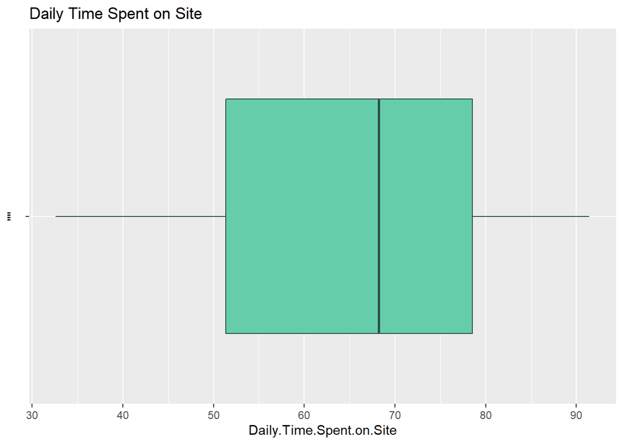

```r
#Using a Box plot to summarize the distribution of the numeric variables:
qplot( x =  Daily.Time.Spent.on.Site, y = "", geom = "boxplot", data = Adv, col = I("darkslategray"), fill = I("aquamarine3"), main = "Daily Time Spent on Site")
```

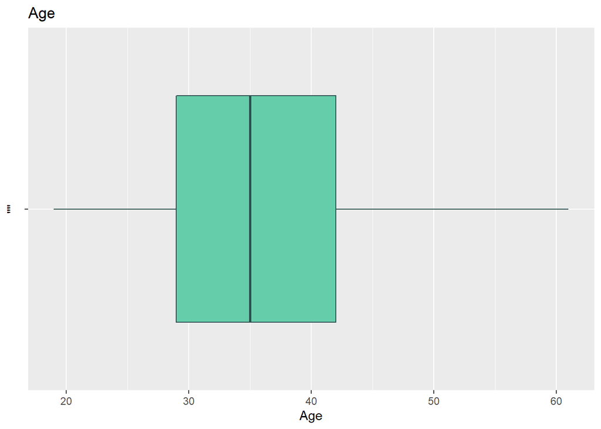

```r
qplot( x =  Age, y = "", geom = "boxplot", data = Adv, col = I("darkslategray"), fill = I("aquamarine3"), main = "Age")
```

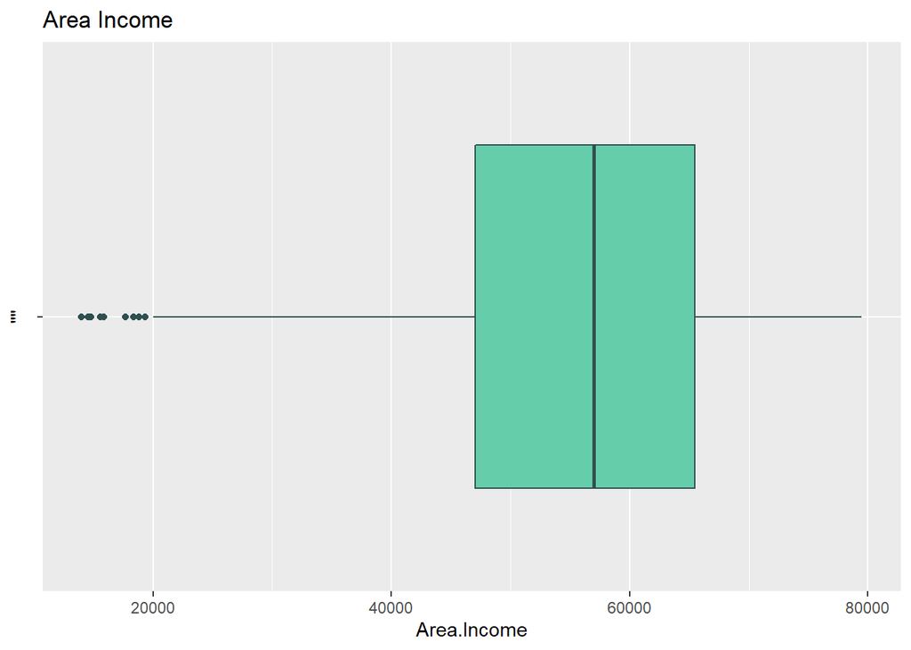

```r
qplot( x =  Area.Income, y = "", geom = "boxplot", data = Adv,col = I("darkslategray"), fill = I("aquamarine3"), main = "Area Income")
```

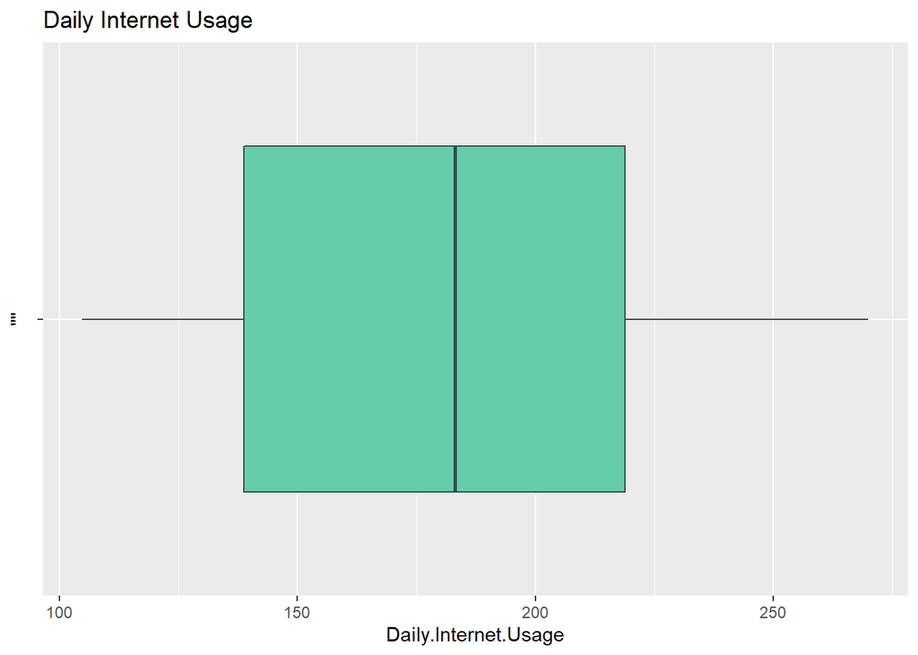

```r
qplot( x =  Daily.Internet.Usage, y = "", geom = "boxplot", data = Adv, col = I("darkslategray"), fill = I("aquamarine3"), main = "Daily Internet Usage")
```

From the Plots above:

Outliers can be observed on the Area Income column. Since there’s no basis to assume the entries are not valid observations, no outliers are dropped.

## 2. Exploratory Data Analysis

#Univariate Analysis

This analysis aims to explore each variable in the dataset separately